# **Visualisasi Data dengan R**

Kumpulan kode untuk membuat berbagai grafik menggunakan bahasa pemrograman R

Ditulis oleh : Panggah D. Putra

Update terakhir : 02 March 2022

## **Prakata**

Website ini saya susun dalam rangka belajar visualisasi data menggunakan bahasa pemrograman R sekaligus belajar R Markdown, serta belajar lain-lain, panjang untuk disebutkan. Tentu saja, website ini masih dalam proses penyelesaian!

Jika anda membuka website ini dengan *handphone*, demi tampilan yang lebih nyaman, saya sarankan untuk menggunakan tampilan situs desktop.

## **Pendahuluan**

Sebelum melangkah lebih jauh, saya asumsikan anda sudah cukup memahami bahasa pemrograman R dan sudah menginstal [R](https://cran.r-project.org/) dan [Rstudio](https://www.rstudio.com/products/rstudio/#Desktop).

Grafik dalam website ini diklasifikasikan berdasarkan klasifikasi pada [Financial Times Visual Vocabulary](https://github.com/Financial-Times/chart-doctor/tree/main/visual-vocabulary) dengan tambahan dari berbagai sumber.

Berdasarkan **Financial Times Visual Vocabulary**, grafik dibagi ke dalam beberapa tipe antara lain:

- Deviasi
- Korelasi
- Peringkat
- Distribusi

Grafik dalam website ini dibuat dengan menggunakan beberapa dataset. Sebagian besar grafik pada tipe grafik-deviasi, korelasi, dan peringkat dibuat dengan menggunakan gapminder dataset dengan beberapa proses manipulasi data.

Sebagian besar grafik pada tipe grafik-distribusi dibuat dengan menggunakan dataset `main_df`, terinsiprasi dari [flipbook_script.R](https://osf.io/vt2ny/) yang disebut oleh Cédric Scherer dalam websitenya, [Beyond Bar and Box Plots](https://z3tt.github.io/beyond-bar-and-box-plots/#import-data).

Seluruh grafik dalam website ini dibuat dengan menggunakan palet warna [Navajo Palette](https://github.com/BlakeRMills/MetBrewer#navajo) dari MetBrewer.

## **Prasyarat**

Seperti yang sudah disebutkan sebelumnya, saya asumsikan anda sudah cukup memahami bahasa pemrograman R dan sudah menginstal R dan Rstudio.

### *Install Packages*

Pertama, instal terlebih dahulu (jika belum pernah diinstal sebelumnya) *package-package* yang akan digunakan dalam membuat grafik.

`install.packages('tidyverse')`  
`install.packages('scales')`  
`install.packages('datasets')`  
`install.packages('gapminder')`  
`install.packages('geomtextpath')`  
`install.packages('CGPfunctions')`  
`install.packages('ggbump')`  
`install.packages('ggalt')`  
`install.packages('ggdist')`  
`install.packages('ggbeeswarm')`  
`install.packages('patchwork')`  
`install.packages('ggridges')`

### *Load Packages*

Selanjutnya, *load* package yang sebelumnya sudah diinstal.

```r
library(tidyverse)    # untuk manupulasi, merapikan, & visualisasi data
library(scales)       # untuk manipulasi data
library(datasets)     # untuk mengakses iris dataset
library(gapminder)    # untuk mengakses gapminder dataset
library(geomtextpath) # untuk membuat Line Text
library(CGPfunctions) # untuk membuat Slope Graph
library(ggbump)       # untuk membuat Bump Chart
library(ggalt)        # untuk membuat Dumbbell Plot
library(ggdist)       # untuk membuat Stat Dot Plot
library(ggbeeswarm)   # untuk membuat Beeswarm Plot
library(patchwork)    # untuk membuat Population Pyramid
library(ggridges)     # untuk membuat Stat Density Ridges Plot
```

### Penyiapan Dataset

Sebagian besar grafik pada tipe grafik-deviasi, korelasi, dan peringkat dibuat dengan menggunakan **gapminder** dataset dengan beberapa proses manipulasi data.

```r
head(gapminder, 5)
```

| country | continent | year | lifeExp | pop | gdpPercap |
| --- | --- | --- | --- | --- | --- |
| Afghanistan | Asia | 1952 | 28.801 | 8425333 | 779.4453 |
| Afghanistan | Asia | 1957 | 30.332 | 9240934 | 820.8530 |
| Afghanistan | Asia | 1962 | 31.997 | 10267083 | 853.1007 |
| Afghanistan | Asia | 1967 | 34.020 | 11537966 | 836.1971 |
| Afghanistan | Asia | 1972 | 36.088 | 13079460 | 739.9811 |

Sebagian besar grafik pada tipe grafik-distribusi dibuat dengan menggunakan dataset `main_df` di bawah ini.

```r
set.seed(2000)
df1 = tibble(var = 'A', val = rnorm(n = 25, mean = 5.5, sd = 1.5))
df2 = tibble(var = 'B', val = rnorm(n = 15, mean = 4.5, sd = 1.0))
df3 = tibble(var = 'C', val = rnorm(n = 20, mean = 5.0, sd = 1.0))
df4 = tibble(var = 'D', val = rnorm(n = 10, mean = 4.0, sd = 0.5))
df5 = tibble(var = 'E', val = rnorm(n = 13, mean = 5.0, sd = 1.5))

main_df <- rbind(df1, df2, df3, df4, df5) %>%
  mutate(Variable = as_factor(var),
         value = round(val, 2)) %>%
  select(Variable, value)
```

Dot Strip Plot pada tipe grafik-peringkat dibuat dengan menggunakan `rank_dot_strip_plot_df` di bawah ini.

```r
set.seed(2000)
df1 = tibble(var1 = 'Variable 1',
             var2 = c('A','B','C','D','E','A','B','C','D','E'),
             val = sample(1:20, 10))
df2 = tibble(var1 = 'Variable 2',
             var2 = c('A','B','C','D','E','A','B','C','D','E'),
             val = sample(1:20, 10))
df3 = tibble(var1 = 'Variable 3',
             var2 = c('A','B','C','D','E','A','B','C','D','E'),
             val = sample(1:20, 10))
df4 = tibble(var1 = 'Variable 4',
             var2 = c('A','B','C','D','E','A','B','C','D','E'),
             val = sample(1:20, 10))
df5 = tibble(var1 = 'Variable 5',
             var2 = c('A','B','C','D','E','A','B','C','D','E'),
             val = sample(1:20, 10))

rank_dot_strip_plot_df <- rbind(df1, df2, df3, df4, df5)
```

Population Pyramid dibuat dengan menggunakan dataset `df_for_pop_pyramid` di bawah ini.

```r
set.seed(2000)
df1 = tibble(gender = 'Male', age = '15-20',
             value = sample((5:10), size = 1))
df2 = tibble(gender = 'Male', age = '21-25',
             value = sample((10:15), size = 1))
df3 = tibble(gender = 'Male', age = '26-30',
             value = sample((15:20), size = 1))
df4 = tibble(gender = 'Male', age = '31-35',
             value = sample((20:25), size = 1))
df5 = tibble(gender = 'Male', age = '36-40',
             value = sample((25:30), size = 1))
df6 = tibble(gender = 'Male', age = '41-45',
             value = sample((30:35), size = 1))
df7 = tibble(gender = 'Male', age = '46-50',
             value = sample((35:40), size = 1))
df8 = tibble(gender = 'Male', age = '51-55',
             value = sample((40:45), size = 1))
df9 = tibble(gender = 'Male', age = '56-60',
             value = sample((45:50), size = 1))
df10 = tibble(gender = 'Female', age = '15-20',
              value = sample((5:10), size = 1))
df11 = tibble(gender = 'Female', age = '21-25',
              value = sample((10:15), size = 1))
df12 = tibble(gender = 'Female', age = '26-30',
              value = sample((15:20), size = 1))
df13 = tibble(gender = 'Female', age = '31-35',
              value = sample((20:25), size = 1))
df14 = tibble(gender = 'Female', age = '36-40',
              value = sample((25:30), size = 1))
df15 = tibble(gender = 'Female', age = '41-45',
              value = sample((30:35), size = 1))
df16 = tibble(gender = 'Female', age = '46-50',
              value = sample((35:40), size = 1))
df17 = tibble(gender = 'Female', age = '51-55',
              value = sample((40:45), size = 1))
df18 = tibble(gender = 'Female', age = '56-60',
              value = sample((45:50), size = 1))

df_for_pop_pyramid <- rbind(df1, df2, df3, df4, df5, df6,
                            df7, df8, df9, df10, df11, df12,
                            df13, df14, df15, df16, df17, df18) %>%
  mutate(age = as.factor(age))
```

Cumulative Curve dibuat dengan menggunakan dataset `df_for_cum_curve` di bawah ini.

```r
set.seed(123)
df_for_cum_curve = tibble(
  var = c('A', 'A', 'A', 'A', 'A', 'A', 'A', 'A',
          'B', 'B', 'B', 'B', 'B', 'B', 'B', 'B'),
  year = c('2015', '2016', '2017', '2018',
           '2019', '2020', '2021', '2022',
           '2015', '2016', '2017', '2018',
           '2019', '2020', '2021', '2022'),
  val = c(sample(10:50, size = 4, replace = TRUE),
          sample(50:100, size = 4, replace = TRUE),
          sample(10:50, size = 4, replace = TRUE),
          sample(50:100, size = 4, replace = TRUE)))

df_for_cum_curve <- df_for_cum_curve %>%
  group_by(var) %>%
  mutate(cumulative_val = cumsum(val))
```

### Penyiapan Palet Warna

Seluruh grafik dalam website ini dibuat dengan menggunakan palet warna `our_palette` dari **Navajo Palette** di **MetBrewer**. Kode hex disalin secara manual untuk mempersempit fokus latihan. Jika tidak ingin menyalin code hex secara manual, penggunaan palet warna pada **MetBrewer** dapat dipelajari sendiri [di sini](https://github.com/BlakeRMills/MetBrewer/tree/main#functions) .

```r
our_palette <-c('#660d20',
                '#e59a52',
                '#edce79',
                '#094568',
                '#e1c59a')
```

### Penyiapan Tema Grafik

Seluruh grafik dalam website ini menggunakan tema `our_theme` di bawah ini.

```r
our_theme <- theme_minimal() +
  theme(
    plot.title = element_text(color = '#660d20',
                              hjust = 0.5,
                              face = 'bold'),
    plot.subtitle = element_text(color = '#660d20',
                                 hjust = 0.5),
    plot.caption = element_text(color = '#660d20',
                                hjust = 1),
    axis.title = element_text(color = '#660d20',
                              face = 'bold'),
    axis.text = element_text(color = '#660d20',
                             face = 'bold'),
    axis.line = element_line(color = '#660d20',
                               size = .5),
    legend.position = 'none',
    panel.grid.minor = element_blank(),
    panel.background = element_rect(fill = '#ffffff',
                                    color = NA),
    plot.background = element_rect(fill = '#ffffff',
                                   color = 'lightblue')
  )
```

## **Deviasi**

Tipe grafik-deviasi digunakan untuk menekankan variasi positif/negatif dari titik referensi tertentu. Tipe grafik-deviasi juga dapat digunakan untuk menunjukkan sentimen positif/netral/negatif.

### Diverging Bar

```r
diverging_bar_df <- gapminder %>%
  filter(continent == 'Asia',
         year == 2007) %>%
  mutate(median_lifeExp = median(lifeExp),
         lifeExp_gap = lifeExp - median_lifeExp) %>%
  filter(between(lifeExp_gap, -12, 12))
```

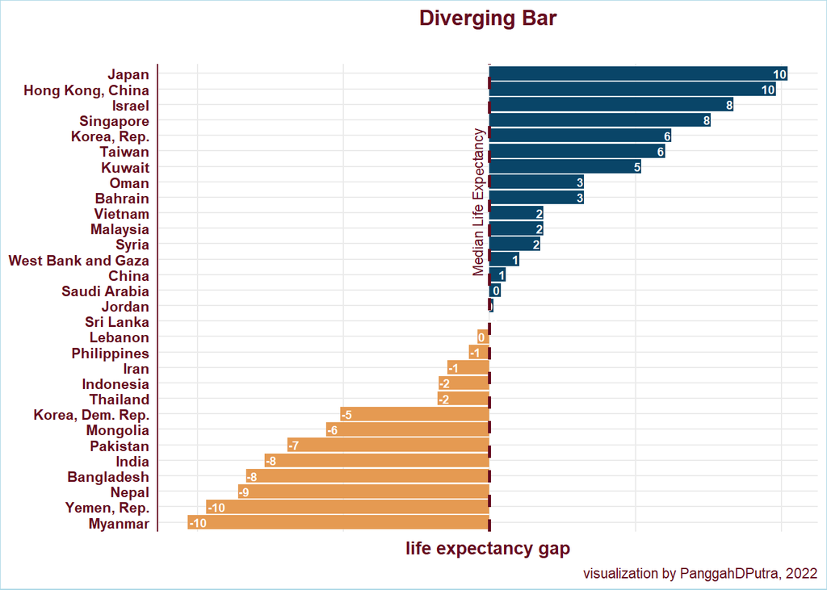

```r
diverging_bar <- diverging_bar_df %>%
  ggplot(aes(x = lifeExp_gap,
             y = reorder(country, lifeExp_gap),
             fill = lifeExp_gap)) +
  geom_col(fill = if_else(diverging_bar_df$lifeExp_gap > 0,
                          '#094568',
                          '#e59a52')) +
  geom_text(aes(label = round(lifeExp_gap, 0),
                hjust = ifelse(lifeExp_gap > 0, 1.1, -.1)),
            size = 2.5,
            fontface = 'bold',
            color = 'white') +
  geom_textvline(xintercept = 0,
                 label = 'Median Life Expectancy',
                 size = 3,
                 vjust = -0.5,
                 hjust = .8,
                 linewidth = 1,
                 linecolor = '#660d20',
                 linetype = 2,
                 color = '#660d20') +
  our_theme +
  theme(
    axis.title.y = element_blank(),
    axis.text.x = element_blank(),
    axis.line.x = element_blank()
  ) +
  xlab('life expectancy gap') +
  labs(title = 'Diverging Bar',
       subtitle = '',
       caption = 'visualization by PanggahDPutra, 2022')
```

### Diverging Stacked Bar

```r
diverging_stacked_bar_df <- gapminder %>%
  filter(year == 2007) %>%
  mutate(median_lifeExp = median(lifeExp)) %>%
  group_by(continent) %>%
  summarize(below_med = sum(lifeExp < median_lifeExp)/n(),
            beyond_med = sum(lifeExp >= median_lifeExp)/n()) %>%
  pivot_longer(!continent,
               names_to = 'cluster',
               values_to = 'percent_country') %>%
  mutate(percent_country = if_else(cluster == 'below_med',
                                   -percent_country,
                                   percent_country))
```

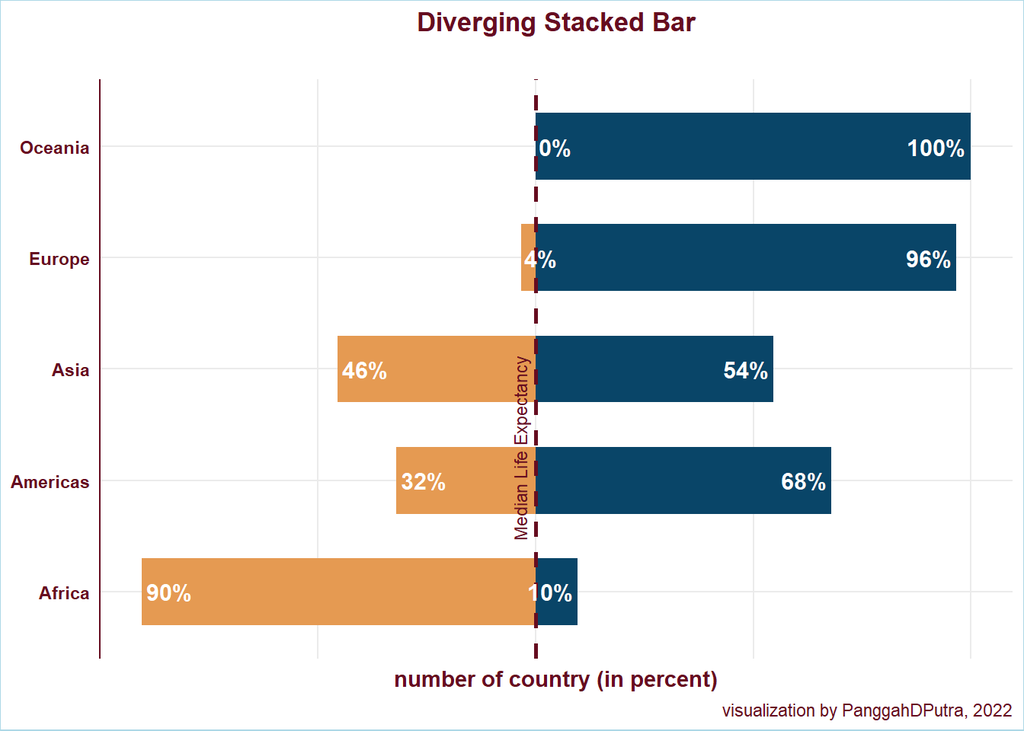

```r
diverging_stacked_bar <- diverging_stacked_bar_df %>%
  ggplot(aes(x = percent_country,
             y = continent,
             fill = cluster)) +
  geom_col(width = .6,
           fill = if_else(diverging_stacked_bar_df$percent_country > 0,
                          '#094568',
                          '#e59a52')) +
  geom_textvline(xintercept = 0,
                 label = 'Median Life Expectancy',
                 size = 3,
                 vjust = -0.5,
                 hjust = .3,
                 linewidth = 1,
                 linecolor = '#660d20',
                 linetype = 2,
                 color = '#660d20') +
  geom_text(aes(label = scales::percent(abs(percent_country), 2),
                hjust = ifelse(percent_country > 0, 1.1, -.1)),
            size = 4,
            fontface = 'bold',
            color = 'white') +
  our_theme +
  theme(
    axis.title.y = element_blank(),
    axis.text.x = element_blank(),
    axis.line.x = element_blank()
  ) +
  xlab('number of country (in percent)') +
  labs(title = 'Diverging Stacked Bar',
       subtitle = '',
       caption = 'visualization by PanggahDPutra, 2022')
```

### Spine

```r
spine_df <- gapminder %>%
  filter(year == 2007) %>%
  mutate(median_lifeExp = median(lifeExp)) %>%
  group_by(continent) %>%
  summarize(below_med = sum(lifeExp < median_lifeExp),
            beyond_med = sum(lifeExp >= median_lifeExp)) %>%
  pivot_longer(!continent,
               names_to = 'cluster',
               values_to = 'percent_country') %>%
  mutate(percent_country = if_else(cluster == 'below_med',
                                   -percent_country,
                                   percent_country))
```

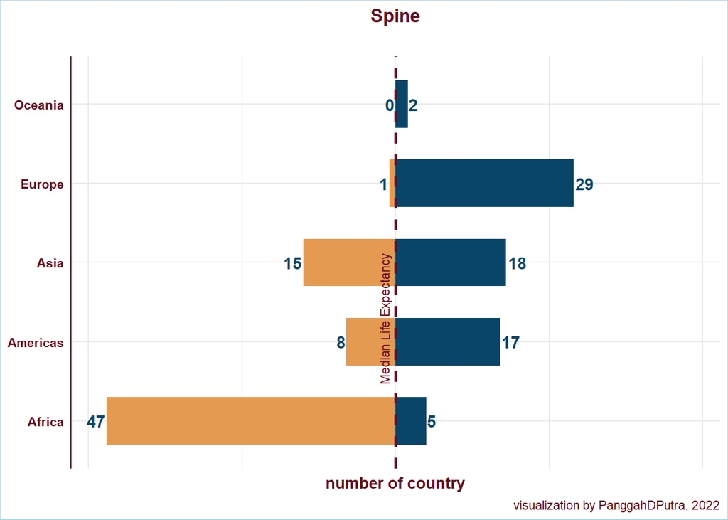

```r
spine <- spine_df %>%
  ggplot(aes(x = percent_country,
             y = continent,
             fill = cluster)) +
  geom_col(width = .6,
           fill = if_else(spine_df$percent_country > 0,
                          '#094568',
                          '#e59a52')) +
  geom_text(aes(label = abs(percent_country),
                hjust = ifelse(percent_country > 0, -.1, 1.1)),
            size = 4,
            fontface = 'bold',
            color = '#094568') +
  geom_textvline(xintercept = 0,
                 label = 'Median Life Expectancy',
                 size = 3,
                 vjust = -0.5,
                 hjust = .3,
                 linewidth = 1,
                 linecolor = '#660d20',
                 linetype = 2,
                 color = '#660d20') +
  scale_x_continuous(limits = c(-48, 48)) +
  our_theme +
  theme(
    axis.title.y = element_blank(),
    axis.text.x = element_blank(),
    axis.line.x = element_blank()
  ) +
  xlab('number of country') +
  labs(title = 'Spine',
       subtitle = '',
       caption = 'visualization by PanggahDPutra, 2022')
```

### Surplus/Deficit Filled Line

```r
s_d_filled_line_df <- gapminder %>%
  filter(continent == 'Asia') %>%
  group_by(year) %>%
  mutate(median_gdp = median(gdpPercap),
         gdp_gap = gdpPercap - median_gdp) %>%
  filter(country == 'Jordan')
```

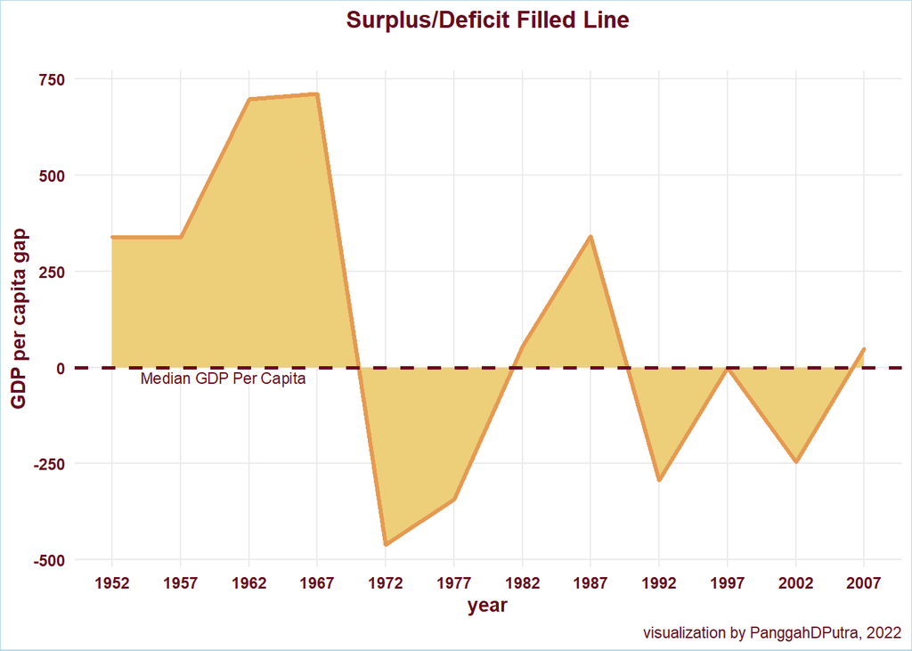

```r
s_d_filled_line <- s_d_filled_line_df %>%
  ggplot(aes(x = year,
             y = gdp_gap)) +
  geom_area(color ='#e59a52',
            size = 1.2,
            fill = '#edce79') +
  geom_texthline(yintercept = 0,
                 label = 'Median GDP Per Capita',
                 size = 3,
                 vjust = 1.2,
                 hjust = .1,
                 linewidth = 1,
                 linecolor = '#660d20',
                 linetype = 2,
                 color = '#660d20') +
  scale_x_continuous(limits = c(1952, 2007),
                     breaks = seq(1952, 2007, by = 5)) +
  our_theme +
  theme(
    axis.line = element_blank()
  ) +
  ylab('GDP per capita gap') +
  labs(title = 'Surplus/Deficit Filled Line',
       subtitle = '',
       caption = 'visualization by PanggahDPutra, 2022')
```

## **Korelasi**

Tipe grafik-korelasi digunakan untuk menyajikan hubungan antara dua variabel atau lebih.

### Scatter Plot

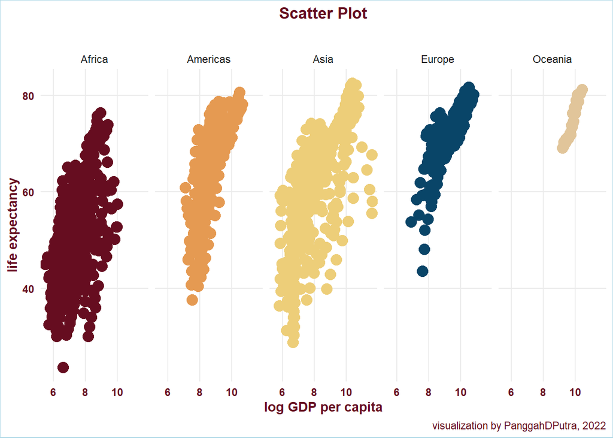

```r
scatter_plot <- gapminder %>%
  ggplot(aes(x = log(gdpPercap),
             y = lifeExp,
             color = continent)) +
  geom_point(size = 4) +
  scale_color_manual(values = our_palette,
                     guide = 'none') +
  our_theme +
  theme(
    axis.line = element_blank()
  ) +
  xlab('log GDP per capita') +
  ylab('life expectancy') +
  facet_grid(. ~ continent) +
  labs(title = 'Scatter Plot',
       subtitle = '',
       caption = 'visualization by PanggahDPutra, 2022')
```

### Scatter Plot with Regression Line

Pada scatter plot juga dapat ditambahkan garis regresi linear dari 2 variabel yang disajikan.

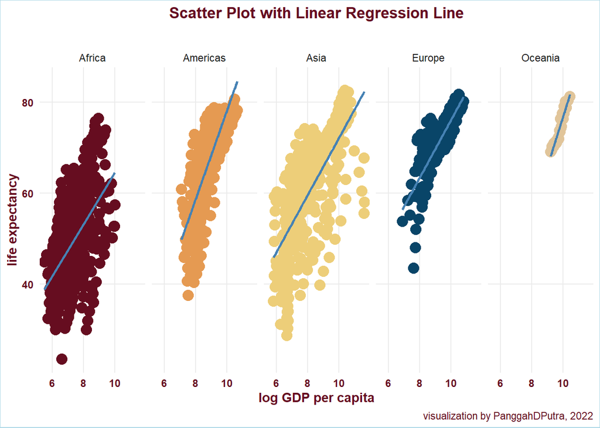

```r
scatter_plot_reg_line <- gapminder %>%
  ggplot(aes(x = log(gdpPercap),
             y = lifeExp,
             color = continent)) +
  geom_point(size = 4) +
  geom_smooth(method = 'lm',
              se = FALSE,
              color = '#4682B4') +
  scale_color_manual(values = our_palette,
                     guide = 'none') +
  our_theme +
  theme(
    axis.line = element_blank()
  ) +
  xlab('log GDP per capita') +
  ylab('life expectancy') +
  facet_grid(. ~ continent) +
  labs(title = 'Scatter Plot with Linear Regression Line',
       subtitle = '',
       caption = 'visualization by PanggahDPutra, 2022')
```

### Column + Line Timeline

```r
col_line_tl_df <- gapminder %>%
  filter(country == 'Indonesia')
```

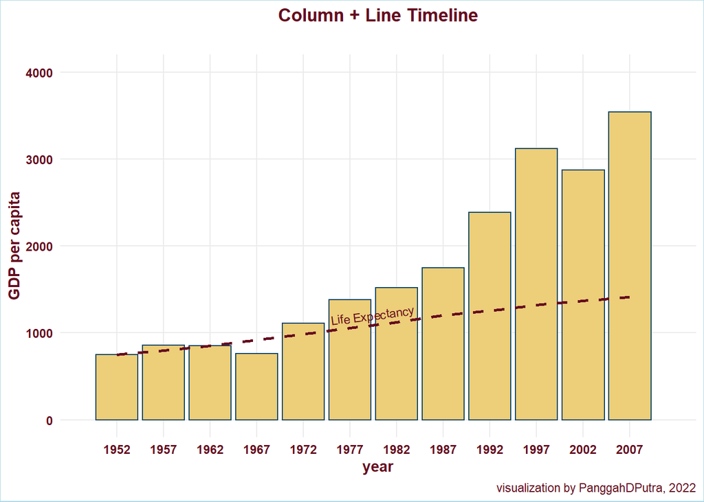

```r
col_line_tl <- col_line_tl_df %>%
  ggplot(aes(x = year,
             y = gdpPercap)) +
  geom_col(color = '#094568',
           fill = '#edce79') +
  geom_textline(aes(x = year,
                    y = lifeExp*20),
                label = 'Life Expectancy',
                size = 3,
                vjust = -0.5,
                linewidth = 1,
                linecolor = '#660d20',
                linetype = 2,
                color = '#660d20') +
  scale_x_continuous(limits = c(1949, 2011),
                     breaks = seq(1952, 2007, by = 5)) +
  scale_y_continuous(limits = c(0, 4000),
                     breaks = seq(0, 4000, by = 1000)) +
  our_theme +
  theme(
    axis.line = element_blank()
  ) +
  ylab('GDP per capita') +
  labs(title = 'Column + Line Timeline',
       subtitle = '',
       caption = 'visualization by PanggahDPutra, 2022')
```

### Connected Scatter Plot

```r
con_scatter_plot_df <- gapminder %>%
  filter(country == 'Indonesia')
```

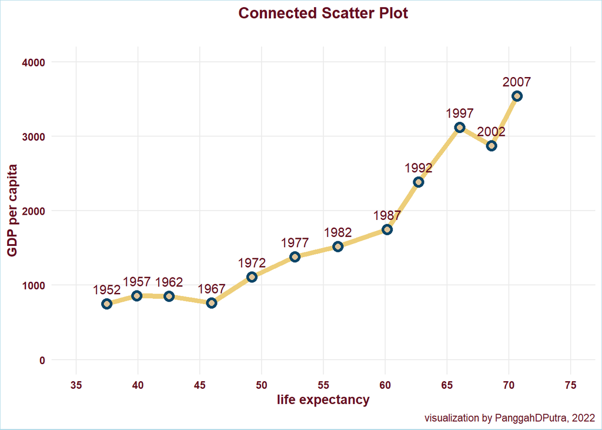

```r
con_scatter_plot <- con_scatter_plot_df %>%
  ggplot(aes(x = lifeExp,
             y = gdpPercap)) +
  geom_path(size = 2,
            color = '#edce79') +
  geom_point(size = 4,
             color = '#094568') +
  geom_point(size = 2,
             color = '#e1c59a') +
  geom_text(aes(label = year),
            color = '#660d20',
            vjust = -1) +
  scale_x_continuous(limits = c(35, 75),
                     breaks = seq(35, 75, by = 5)) +
  scale_y_continuous(limits = c(0, 4000),
                     breaks = seq(0, 4000, by = 1000)) +
  our_theme +
  theme(
    axis.line = element_blank()
  ) +
  xlab('life expectancy') +
  ylab('GDP per capita') +
  labs(title = 'Connected Scatter Plot',
       subtitle = '',
       caption = 'visualization by PanggahDPutra, 2022')
```

### Bubble

```r
bubble_df <- gapminder %>%
  filter(continent == 'Oceania')
```

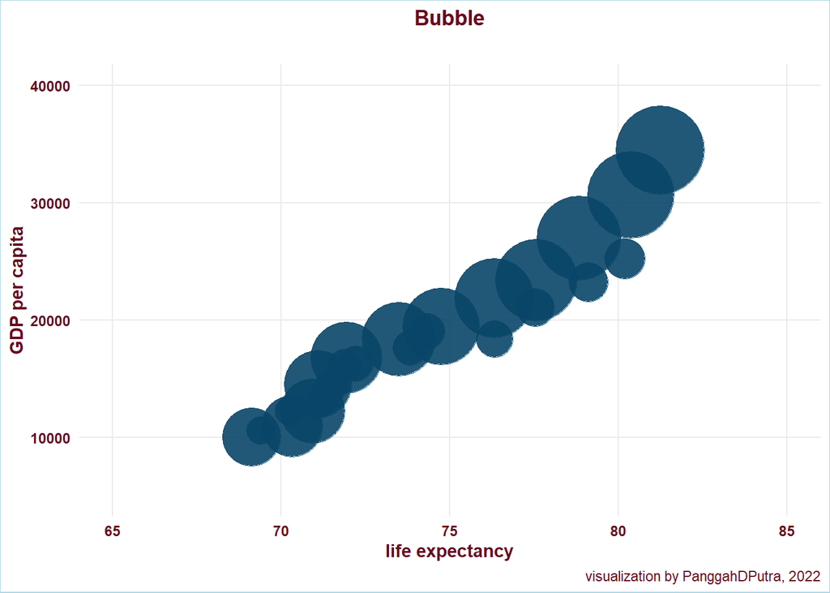

```r
bubble <- bubble_df %>%
  ggplot(aes(x = lifeExp,
             y = gdpPercap,
             color = country,
             size = pop)) +
  geom_point(alpha = 0.9,
             color = '#094568') +
  scale_size_area(max_size = 25,
                  guide = 'none') +
  scale_x_continuous(limits = c(65, 85),
                     breaks = seq(65, 85, by = 5)) +
  scale_y_continuous(limits = c(5000, 40000),
                     breaks = seq(10000, 40000, by = 10000)) +
  our_theme +
  theme(
    axis.line = element_blank()
  ) +
  xlab('life expectancy') +
  ylab('GDP per capita') +
  labs(title = 'Bubble',
       subtitle = '',
       caption = 'visualization by PanggahDPutra, 2022')
```

### XY Heatmap

```r
xy_heatmap_df <- gapminder %>%
  mutate(year = as.factor(year)) %>%
  group_by(continent, year) %>%
  summarize(MedlifeExp = round(median(lifeExp), 0))
```

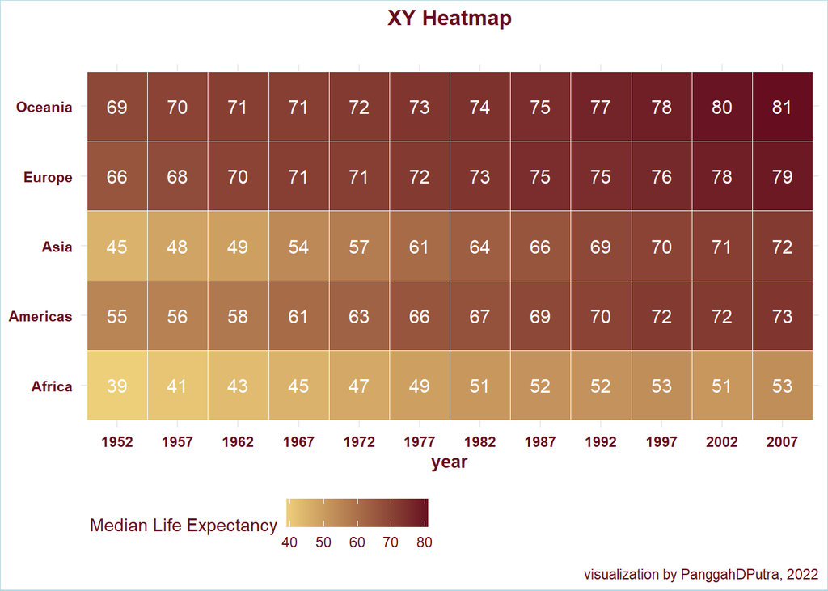

```r
xy_heatmap <- xy_heatmap_df %>%
  ggplot(aes(x = year,
             y = continent,
             fill = MedlifeExp)) +
  geom_tile(color = '#FFFFFF') +
  geom_text(aes(label = MedlifeExp),
            size = 4,
            color = '#FFFFFF') +
  scale_fill_gradient(name = 'Median Life Expectancy',
                      low = '#edce79',
                      high = '#660d20') +
  our_theme +
  theme(
    axis.title.y = element_blank(),
    axis.line = element_blank()
  ) +
  theme(legend.title = element_text(color = '#660d20'),
        legend.text = element_text(color = '#660d20'),
        legend.position = 'bottom',
        legend.justification = 'left') +
  labs(title = 'XY Heatmap',
       subtitle = '',
       caption = 'visualization by PanggahDPutra, 2022')
```

## **Peringkat**

Tipe grafik-peringkat digunakan untuk mengurutkan variabel berdasarkan nilai tertentu yang dimiliki masing-masing variabel.

### Ordered Bar

```r
ordered_bar_df <- gapminder %>%
  group_by(continent) %>%
  summarize(medianlifeExp = median(lifeExp))
```

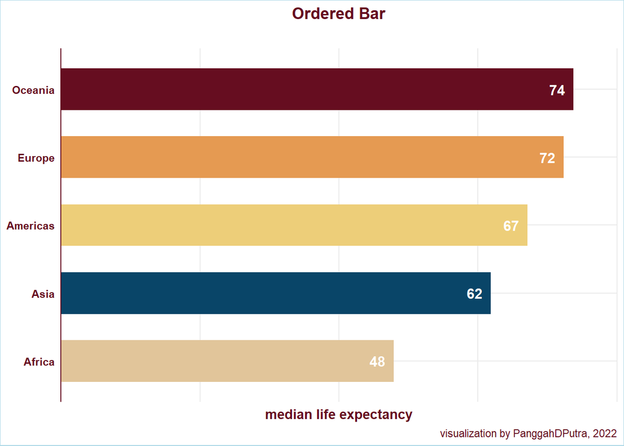

```r
ordered_bar <- ordered_bar_df %>%
  ggplot(aes(x = medianlifeExp,
             y = reorder(continent, medianlifeExp),
             color = reorder(continent, -medianlifeExp),
             fill = reorder(continent, -medianlifeExp))) +
  geom_col(width = .6) +
  geom_text(aes(label = round(medianlifeExp, 0)),
            size = 4,
            hjust = 1.5,
            fontface = 'bold',
            color = 'white') +
  scale_color_manual(values = our_palette,
                     guide = 'none') +
  scale_fill_manual(values = our_palette,
                    guide = 'none') +
  scale_x_continuous(expand = c(0,0),
                     limits = c(0, 80)) +
 our_theme +
  theme(
    axis.title.y = element_blank(),
    axis.text.x = element_blank(),
    axis.line.x = element_blank()
  ) +
  xlab('median life expectancy') +
  labs(title = 'Ordered Bar',
       subtitle = '',
       caption = 'visualization by PanggahDPutra, 2022')
```

### Ordered Column

```r
ordered_column_df <- gapminder %>%
  group_by(continent) %>%
  summarize(medianlifeExp = median(lifeExp))
```

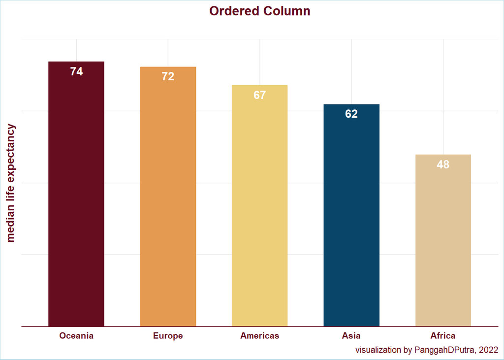

```r
ordered_column <- ordered_column_df %>%
  ggplot(aes(x = reorder(continent, -medianlifeExp),
             y = medianlifeExp,
             color = reorder(continent, -medianlifeExp),
             fill = reorder(continent, -medianlifeExp))) +
  geom_col(width = .6) +
  geom_text(aes(label = round(medianlifeExp, 0)),
            size = 4,
            vjust = 1.5,
            fontface = 'bold',
            color = 'white') +
  scale_color_manual(values = our_palette,
                     guide = 'none') +
  scale_fill_manual(values = our_palette,
                    guide = 'none') +
  scale_y_continuous(expand = c(0,0),
                     limits = c(0, 80)) +
  our_theme +
  theme(
    axis.title.x = element_blank(),
    axis.text.y = element_blank(),
    axis.line.y = element_blank()
  ) +
  ylab('median life expectancy') +
  labs(title = 'Ordered Column',
       subtitle = '',
       caption = 'visualization by PanggahDPutra, 2022')
```

### Ordered Proportional Symbol

```r
ordered_prop_symbol_df <- gapminder %>%
  group_by(continent) %>%
  summarize(medianlifeExp = median(lifeExp))
```

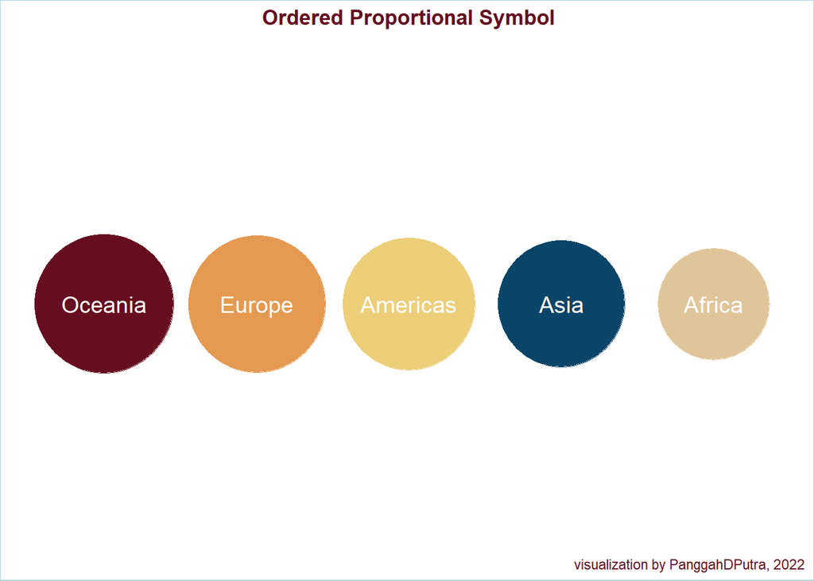

```r
ordered_prop_symbol <- ordered_prop_symbol_df %>%
  ggplot(aes(x = reorder(continent, -medianlifeExp),
             y = 0,
             color = reorder(continent, -medianlifeExp),
             fill = reorder(continent, -medianlifeExp))) +
  geom_point(aes(size = medianlifeExp),
             show.legend = FALSE) +
  geom_text(aes(label = continent),
            size = 5,
            color = 'white') +
  scale_size_area(max_size = 40) +
  scale_color_manual(values = our_palette,
                     guide = 'none') +
  scale_fill_manual(values = our_palette,
                    guide = 'none') +
  scale_y_continuous(limits = c(-1, 1)) +
  our_theme +
  theme(
    axis.title = element_blank(),
    axis.text = element_blank(),
    axis.line = element_blank(),
    panel.grid.major = element_blank()
  ) +
  labs(title = 'Ordered Proportional Symbol',
       subtitle = '',
       caption = 'visualization by PanggahDPutra, 2022')
```

### Dot Strip Plot

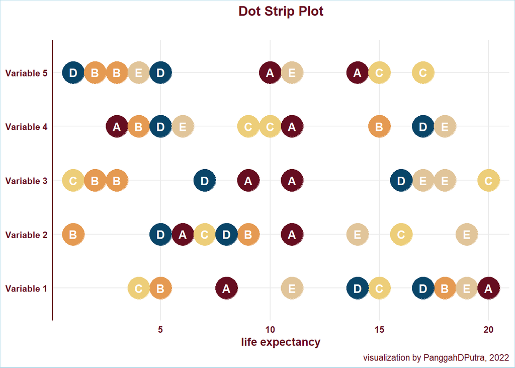

```r
rank_dot_strip_plot <- rank_dot_strip_plot_df %>%
  ggplot(aes(x = val,
             y = var1,
             color = var2,
             fill = var2)) +
  geom_point(size = 10) +
  geom_text(aes(label = var2),
            size = 4,
            fontface = 'bold',
            color = 'white') +
  scale_color_manual(values = our_palette,
                     guide = 'none') +
  scale_fill_manual(values = our_palette,
                    guide = 'none') +
 our_theme +
  theme(
    axis.title.y = element_blank(),
    axis.line.x = element_blank()
  ) +
  xlab('life expectancy') +
  labs(title = 'Dot Strip Plot',
       subtitle = '',
       caption = 'visualization by PanggahDPutra, 2022')
```

### Ordered Dot Strip Plot

Variabel pada dot strip plot juga dapat diurutkan sesuai dengan nilai tertentu. Pada contoh dibawah, Variabel diurutkan berdasarkan median dari masing-masing variabel.

```r
ordered_dot_strip_plot_df <- gapminder %>%
  filter(year == 2007) %>%
  group_by(continent) %>%
  mutate(medianlifeExp = median(lifeExp))
```

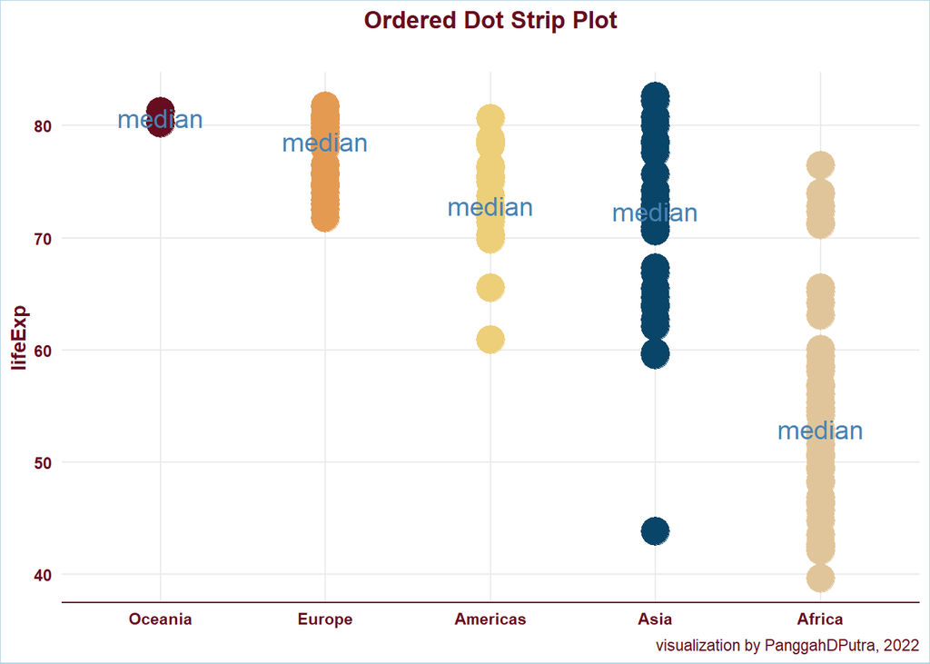

```r
ordered_dot_strip_plot <- ordered_dot_strip_plot_df  %>%
 ggplot(aes(x = reorder(continent, -medianlifeExp),
            y = lifeExp,
            color = reorder(continent, -medianlifeExp),
            fill = reorder(continent, -medianlifeExp))) +
  geom_point(size = 7) +
  scale_color_manual(values = our_palette,
                     guide = 'none') +
  scale_fill_manual(values = our_palette,
                    guide = 'none') +
  stat_summary(fun = 'median',
               geom = 'text',
               label = 'median',
               size = 5,
               color = '#4682B4') +
  our_theme +
  theme(
    axis.title.x = element_blank(),
    axis.line.y = element_blank()
  ) +
  labs(title = 'Ordered Dot Strip Plot',
       subtitle = '',
       caption = 'visualization by PanggahDPutra, 2022')
```

### Slope Graph

```r
slope_graph_df <- gapminder %>%
  filter(year %in% c(1987, 1997, 2007)) %>%
  group_by(continent, year) %>%
  summarize(medianlifeExp = round(median(lifeExp)),0) %>%
  mutate(year = as_factor(year))
```

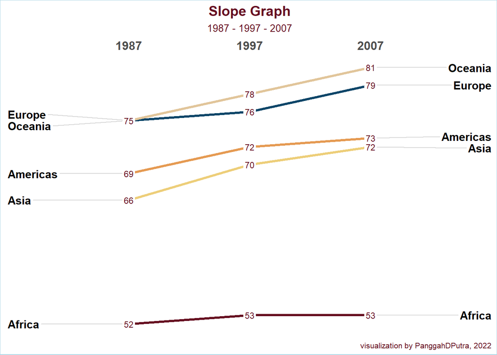

```r
slope_graph <- CGPfunctions::newggslopegraph(
  dataframe = slope_graph_df,
  Times = year,
  Measurement = medianlifeExp,
  Grouping = continent,
  Title = 'Slope Graph',
  SubTitle = '1987 - 1997 - 2007',
  Caption = 'visualization by PanggahDPutra, 2022',
  XTextSize = 12,
  YTextSize = 4,
  TitleTextSize = 14,
  SubTitleTextSize = 10,
  CaptionTextSize = 8,
  TitleJustify = 'center',
  SubTitleJustify = 'center',
  CaptionJustify = 'right',
  LineThickness = 1.2,
  LineColor = our_palette,
  DataTextSize = 3,
  DataTextColor = '#660d20',
  DataLabelPadding = 0.1,
  DataLabelFillColor = '#ffffff',
  WiderLabels = TRUE) +
  theme(plot.title = element_text(color = '#660d20'),
        plot.subtitle = element_text(color = '#660d20'),
        plot.caption = element_text(color = '#660d20'),
        panel.background = element_rect(fill = '#ffffff',
                                        color = NA),
        plot.background = element_rect(fill = '#ffffff',
                                       color = 'lightblue'))
```

### Lollipop

Pada grafik lollipop, perbedaan nilai antar variabel susah untuk dilihat jika selisih nilai tiap variabel sangat tipis. Untuk itu, nilai variabel lebih baik ditampilkan di dalam lingkaran lollipop.

```r
lollipop_df <- gapminder %>%
  group_by(continent) %>%
  summarize(medianlifeExp = round(median(lifeExp),0))
```

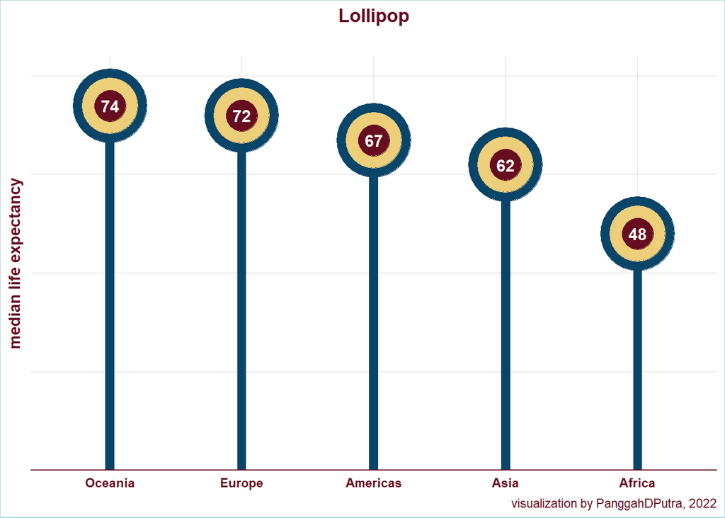

```r
lollipop <-lollipop_df %>%
  ggplot(aes(x = reorder(continent, -medianlifeExp),
             y = medianlifeExp)) +
  geom_col(alpha = 1,
           width = .06,
           color = '#094568',
           fill = '#094568',
           show.legend = FALSE) +
  geom_point(alpha = 1,
             size = 24,
             color = '#094568',
             show.legend = FALSE) +
  geom_point(alpha = 1,
             size = 18,
             color = '#edce79',
             show.legend = FALSE) +
  geom_point(alpha = 1,
             size = 10,
             color = '#660d20',
             show.legend = FALSE) +
  geom_text(aes(label = medianlifeExp),
            size = 4,
            fontface = 'bold',
            color = 'white') +
  scale_y_continuous(expand = c(0,0),
                     limits = c(0, 84)) +
  our_theme +
  theme(
    axis.title.x = element_blank(),
    axis.text.y = element_blank(),
    axis.line.y = element_blank()
  ) +
  ylab('median life expectancy') +
  labs(title = 'Lollipop',
       subtitle = '',
       caption = 'visualization by PanggahDPutra, 2022')
```

### Bump Chart

```r
bump_df <- gapminder %>%
  filter(year %in% c(1967,1977,1987,1997,2007)) %>%
  group_by(continent, year) %>%
  summarize(maxlifeExp = max(lifeExp)) %>%
  group_by(year) %>%
  mutate(ranking = dense_rank(desc(maxlifeExp)))
```

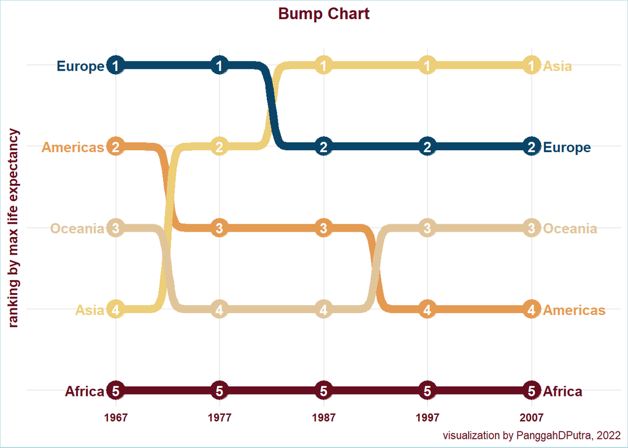

```r
bump <- bump_df %>%
  ggplot(aes(x = year,
             y = ranking,
             color = continent)) +
  ggbump::geom_bump(size = 3,
                    smooth = 20,
                    show.legend = FALSE) +
  geom_point(size = 7) +
  geom_text(aes(label = ranking),
            size = 4,
            fontface = 'bold',
            color = 'white') +
  geom_text(data = bump_df %>% filter(year == 1967),
            aes(x = year - 1.1,
                label = continent),
            size = 4,
            fontface = 'bold',
            hjust = 1) +
  geom_text(data = bump_df %>% filter(year == 2007),
            aes(x = year + 1.1,
                label = continent),
            size = 4,
            fontface = 'bold',
            hjust = 0) +
  scale_color_manual(values = our_palette,
                     guide = 'none') +
  scale_y_reverse() +
  scale_x_continuous(limits = c(1961,2013),
                     breaks = c(1967,1977,1987,1997,2007)) +
  our_theme +
  theme(
    axis.title.x = element_blank(),
    axis.text.y = element_blank(),
    axis.line = element_blank()
  ) +
  ylab('ranking by max life expectancy') +
  labs(title = 'Bump Chart',
       subtitle = '',
       caption = 'visualization by PanggahDPutra, 2022')
```

## **Distribusi**

Tipe grafik-distribusi digunakan untuk menunjukkan distribusi data dari suatu dataset atau dari tiap variabel.

### Histogram

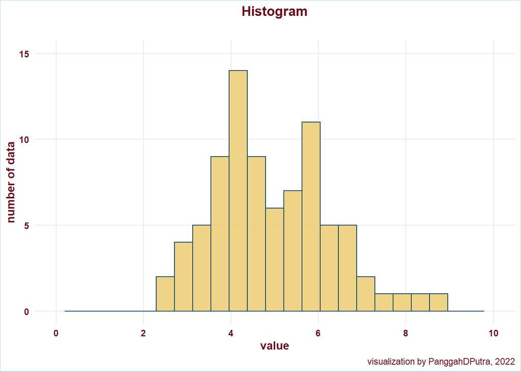

```r
histogram <- main_df %>%
  ggplot(aes(x = value)) +
  geom_histogram(bins = 25,
                 alpha = .9,
                 color = '#094568',
                 fill = '#edce79') +
  scale_x_continuous(limits = c(0,10),
                     breaks = seq(0, 10, by = 2)) +
  scale_y_continuous(limits = c(0, 15),
                     breaks = seq(0, 15, by = 5)) +
  our_theme +
  theme(
    axis.line = element_blank()
  ) +
  ylab('number of data') +
  labs(title = 'Histogram',
       subtitle = '',
       caption = 'visualization by PanggahDPutra, 2022')
```

### Dot Plot (Dumbbell Plot)

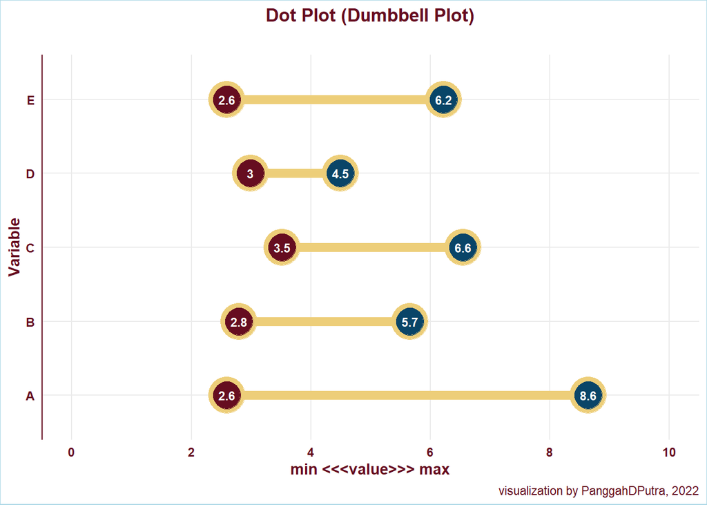

```r
dumbbell_plot <- main_df %>%
  group_by(Variable) %>%
  summarise(min = min(value), max = max(value)) %>%
  ggplot(aes(x = min,
             xend = max,
             y = Variable,
             color = Variable,
             fill = Variable), ) +
  ggalt::geom_dumbbell(size =3,
                       size_x = 12,
                       size_xend = 12,
                       color = '#edce79',
                       colour_x = '#edce79',
                       colour_xend = '#edce79') +
  ggalt::geom_dumbbell(size = 3,
                       size_x = 9,
                       size_xend = 9,
                       color = '#edce79',
                       colour_x = '#660d20',
                       colour_xend = '#094568') +
  geom_text(aes(x = min,
                y = Variable,
                label = round(min, 1)),
            size = 3,
            fontface = 'bold',
            color = 'white') +
  geom_text(aes(x = max,
                y = Variable,
                label = round(max, 1)),
            size = 3,
            fontface = 'bold',
            color = 'white') +
  scale_color_manual(values = our_palette,
                     guide = 'none') +
  scale_fill_manual(values = our_palette,
                    guide = 'none') +
  scale_x_continuous(limits = c(0, 10),
                     breaks = seq(0, 10, by = 2)) +
  our_theme +
  theme(
    axis.line.x = element_blank()
  ) +
  xlab('min <<<value>>> max') +
  labs(title = 'Dot Plot (Dumbbell Plot)',
       subtitle = '',
       caption = 'visualization by PanggahDPutra, 2022')
```

### Dot Strip Plot

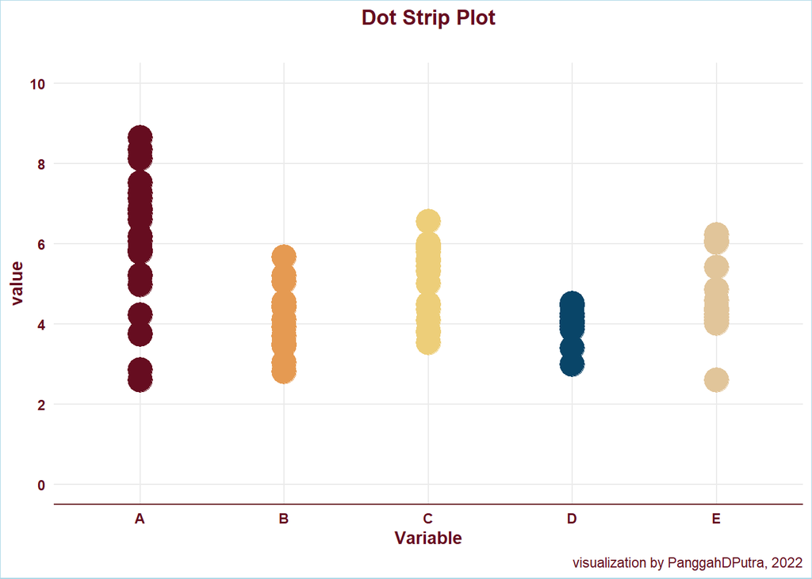

```r
dot_strip_plot <- main_df %>%
  ggplot(aes(x = Variable,
             y = value,
             color = Variable,
             fill = Variable)) +
  geom_point(size = 7) +
  scale_color_manual(values = our_palette,
                     guide = 'none') +
  scale_fill_manual(values = our_palette,
                    guide = 'none') +
  scale_y_continuous(limits = c(0, 10),
                     breaks = seq(0, 10, by = 2)) +
  our_theme +
  theme(
    axis.line.y = element_blank()
  ) +
  labs(title = 'Dot Strip Plot',
       subtitle = '',
       caption = 'visualization by PanggahDPutra, 2022')
```

### Stat Dot Plot

Pada dot strip plot di atas, jumlah data yang memiliki nilai sama/hampir sama - sulit untuk diidentifikasi. Untuk mempermudah identifikasi, kita dapat membuat stat dot plot seperti di bawah ini.

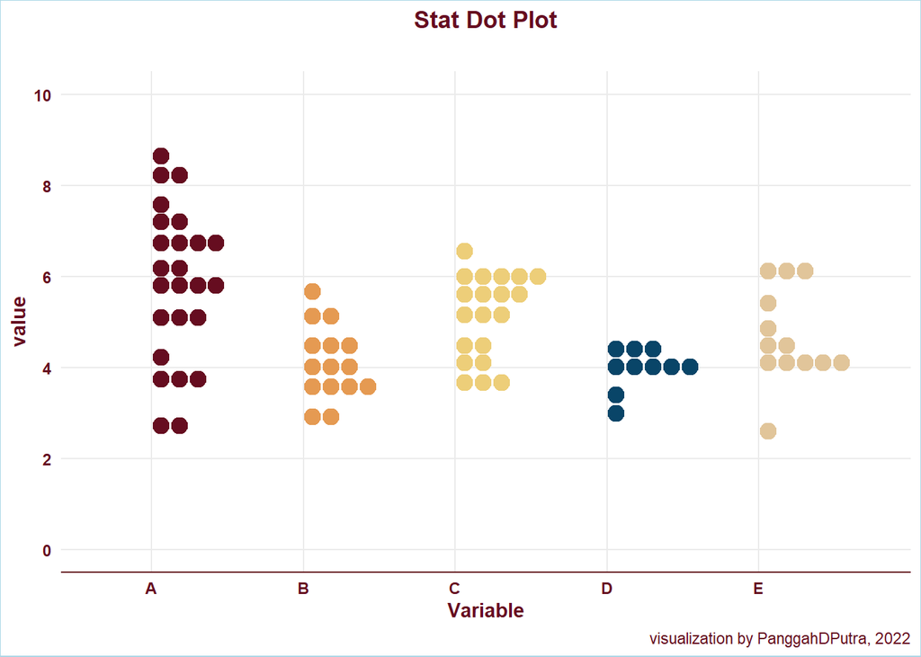

```r
stat_dot_plot <- main_df %>%
  ggplot(aes(x = Variable,
             y = value,
             color = Variable,
             fill = Variable)) +
  ggdist::stat_dots(side = 'right') +
  scale_color_manual(values = our_palette,
                     guide = 'none') +
  scale_fill_manual(values = our_palette,
                    guide = 'none') +
  scale_y_continuous(limits = c(0, 10),
                     breaks = seq(0, 10, by = 2)) +
  our_theme +
  theme(
    axis.line.y = element_blank()
  ) +
  labs(title = 'Stat Dot Plot',
       subtitle = '',
       caption = 'visualization by PanggahDPutra, 2022')
```

### Barcode Plot

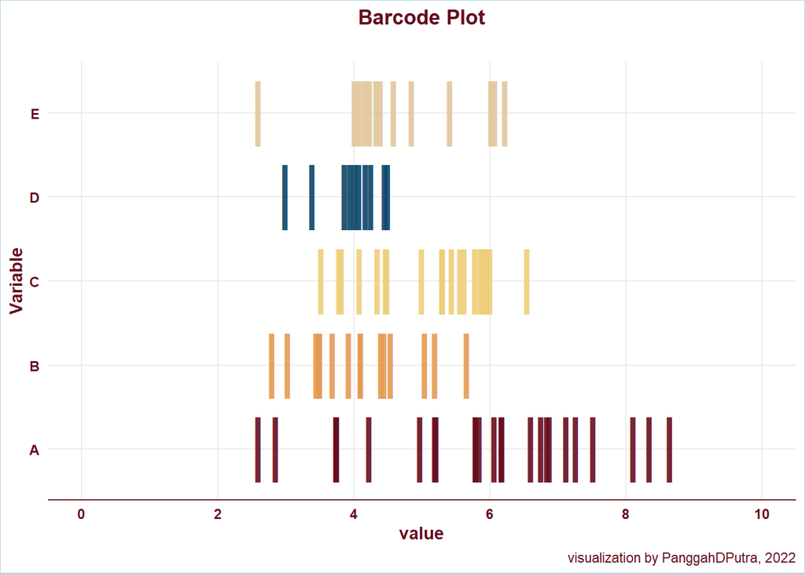

```r
barcode_plot <- main_df %>%
  ggplot(aes(x = value,
             y = Variable,
             color = Variable,
             fill = Variable)) +
  geom_point(shape = 124,
             size = 15,
             alpha = .9) +
  scale_color_manual(values = our_palette,
                     guide = 'none') +
  scale_fill_manual(values = our_palette,
                    guide = 'none') +
  scale_x_continuous(limits = c(0, 10),
                     breaks = seq(0, 10, by = 2)) +
  our_theme +
  theme(
    axis.line.y = element_blank()
  ) +
  labs(title = 'Barcode Plot',
       subtitle = '',
       caption = 'visualization by PanggahDPutra, 2022')
```

### Box Plot

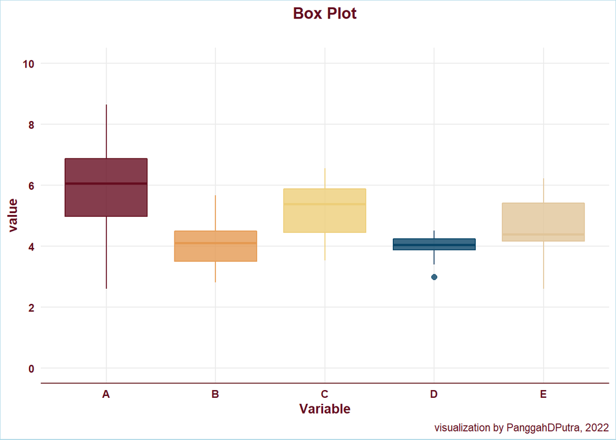

```r
box_plot <- main_df %>%
  ggplot(aes(x = Variable,
             y = value,
             color = Variable,
             fill = Variable)) +
  geom_boxplot(alpha = .8,
               size = .5,
               outlier.size = 2) +
  scale_color_manual(values = our_palette,
                    guide = 'none') +
  scale_fill_manual(values = our_palette,
                    guide = 'none') +
  scale_y_continuous(limits = c(0, 10),
                     breaks = seq(0, 10, by = 2)) +
  our_theme +
  theme(
    axis.line.y = element_blank()
  ) +
  labs(title = 'Box Plot',
       subtitle = '',
       caption = 'visualization by PanggahDPutra, 2022')
```

### Violin Plot

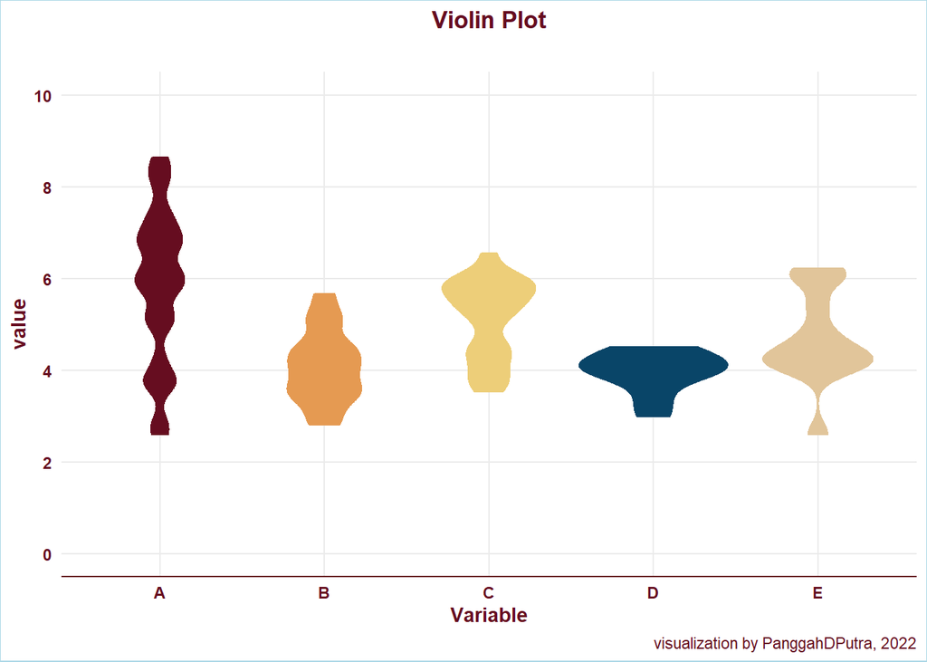

```r
violin_plot <- main_df %>%
  ggplot(aes(x = Variable,
             y = value,
             color = Variable,
             fill = Variable)) +
  geom_violin(size = .5,
              bw = .25) +
  scale_color_manual(values = our_palette,
                     guide = 'none') +
  scale_fill_manual(values = our_palette,
                    guide = 'none') +
  scale_y_continuous(limits = c(0, 10),
                     breaks = seq(0, 10, by = 2)) +
  our_theme +
  theme(
    axis.line.y = element_blank()
  ) +
  labs(title = 'Violin Plot',
       subtitle = '',
       caption = 'visualization by PanggahDPutra, 2022')
```

### Population Pyramid

```r
female_side <- df_for_pop_pyramid %>%
  filter(gender == 'Female') %>%
  ggplot(aes(x = value,
             y = reorder(age, desc(age)),
             fill = gender)) +
  geom_col(fill =  '#094568') +
  geom_text(aes(label = value),
            hjust = 2,
            size = 3,
            fontface = 'bold',
            color = 'white') +
  scale_x_continuous(limits = c(0, 50)) +
  theme_minimal() +
  theme(
    plot.title.position = 'plot',
    plot.subtitle = element_text(color = '#660d20',
                                 face = 'bold'),
    axis.title.x = element_text(color = '#660d20',
                                face = 'bold'),
    axis.title.y = element_blank(),
    axis.text.x = element_blank(),
    axis.text.y = element_text(color = '#660d20',
                               face = 'bold'),
    panel.background = element_rect(fill = '#ffffff',
                                    color = NA),
    plot.background = element_rect(fill = '#ffffff',
                                   color = '#ffffff')
  ) +
  xlab('Female') +
  labs(subtitle = 'Age')
```

```r
male_side <- df_for_pop_pyramid %>%
  filter(gender == 'Male') %>%
  ggplot(aes(x = -value,
             y = reorder(age, desc(age)),
             fill = gender)) +
  geom_col(fill = '#e59a52') +
  geom_text(aes(label = value),
            hjust = -1,
            size = 3,
            fontface = 'bold',
            color = 'white') +
  scale_x_continuous(limits = c(-50, 0)) +
  theme_minimal() +
  theme(
    axis.title.x = element_text(color = '#660d20',
                                face = 'bold'),
    axis.title.y = element_blank(),
    axis.text.x = element_blank(),
    axis.text.y = element_blank(),
    panel.background = element_rect(fill = '#ffffff',
                                    color = NA),
    plot.background = element_rect(fill = '#ffffff',
                                   color = '#ffffff')
  ) +
  xlab('Male')
```

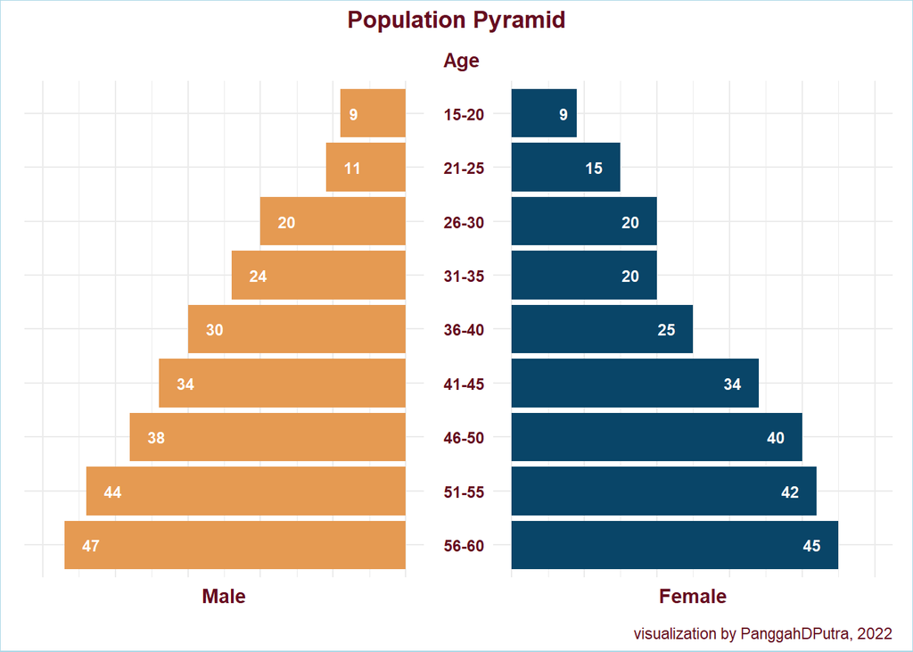

```r
pop_pyramid <- (male_side|female_side) +
  patchwork::plot_annotation(
    title = 'Population Pyramid',
    caption = 'visualization by PanggahDPutra, 2022',
    theme = theme(
      plot.title = element_text(color = '#660d20',
                                hjust = 0.5,
                                face = 'bold'),
      plot.caption = element_text(color = '#660d20',
                                  hjust = 1),
      panel.background = element_rect(fill = '#ffffff',
                                    color = NA),
    plot.background = element_rect(fill = '#ffffff',
                                   color = 'lightblue')))
```

### Cumulative Curve

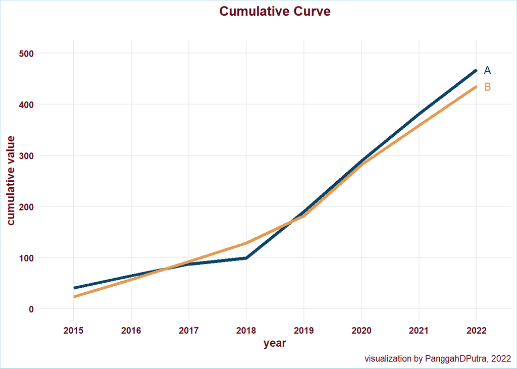

```r
cumulative_curve <- df_for_cum_curve %>%
  ggplot(aes(x = year,
             y = cumulative_val,
             group = var,
             color = var)) +
  geom_line(size = 1.5) +
  geom_text(data = subset(df_for_cum_curve,year == '2022'),
            aes(label = var),
            hjust = -1) +
  scale_color_manual(values = c('#094568', '#e59a52'),
                     guide = 'none') +
  scale_y_continuous(limits = c(0, 500)) +
  our_theme +
  theme(
    axis.line = element_blank()
  ) +
  ylab('cumulative value') +
  labs(title = 'Cumulative Curve',
       subtitle = '',
       caption = 'visualization by PanggahDPutra, 2022')
```

### Frequency Polygons

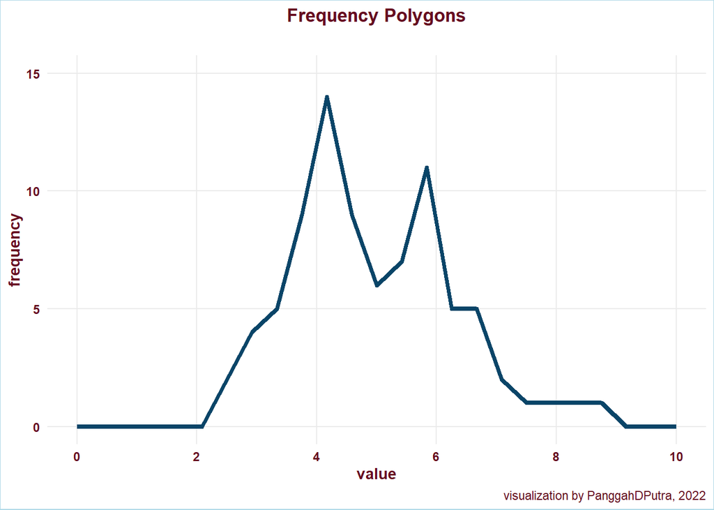

```r
freq_polygons <- main_df %>%
  ggplot(aes(x = value)) +
  geom_freqpoly(bins = 25,
                size = 1.5,
                color = '#094568') +
  scale_x_continuous(limits = c(0, 10),
                     breaks = seq(0, 10, by = 2)) +
  scale_y_continuous(limits = c(0, 15),
                     breaks = seq(0, 15, by = 5)) +
  our_theme +
  theme(
    axis.line = element_blank()
  ) +
  ylab('frequency') +
  labs(title = 'Frequency Polygons',
       subtitle = '',
       caption = 'visualization by PanggahDPutra, 2022')
```

### Beeswarm

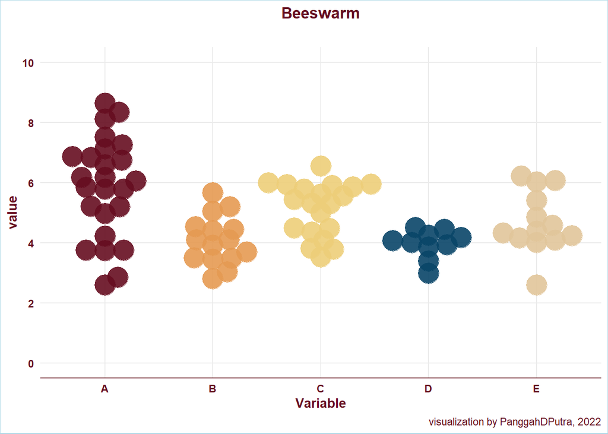

```r
beeswarm <- main_df %>%
  ggplot(aes(x = Variable,
             y = value,
             color = Variable,
             fill = Variable)) +
  ggbeeswarm::geom_beeswarm(alpha = .9,
                            size = 8,
                            cex = 3.5,
                            show.legend = FALSE) +
  scale_color_manual(values = our_palette,
                     guide = 'none') +
  scale_fill_manual(values = our_palette,
                    guide = 'none') +
  scale_y_continuous(limits = c(0, 10),
                     breaks = seq(0, 10, by = 2)) +
  our_theme +
  theme(
    axis.line.y = element_blank()
  ) +
  labs(title = 'Beeswarm',
       subtitle = '',
       caption = 'visualization by PanggahDPutra, 2022')
```

### Density Plot

Density plot menampilkan *density* dari suatu dataset.

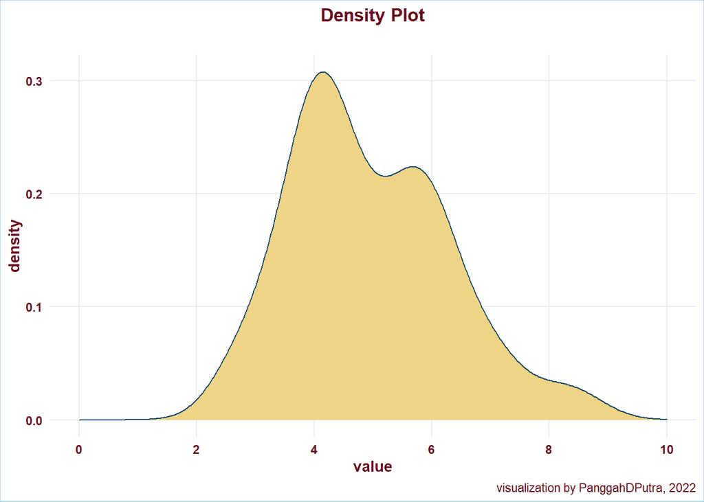

```r
density_plot <- main_df %>%
  ggplot(aes(x = value)) +
  geom_density(alpha = 0.9,
               color = '#094568',
               fill = '#edce79') +
  scale_x_continuous(limits = c(0, 10),
                     breaks = seq(0, 10, by = 2)) +
  our_theme +
  theme(
    axis.line = element_blank()
  ) +
  ylab('density') +
  labs(title = 'Density Plot',
       subtitle = '',
       caption = 'visualization by PanggahDPutra, 2022')
```

### Stat Density Ridges Plot

Tidak seperti density plot, stat density plot menampilkan *density* dari tiap variabel. Stat density plot juga dapat menampilkan nilai quantile dari tiap variabel. Pada stat dot plot di bawah, nilai quantile yang ditampilkan adalah Q2 (median).

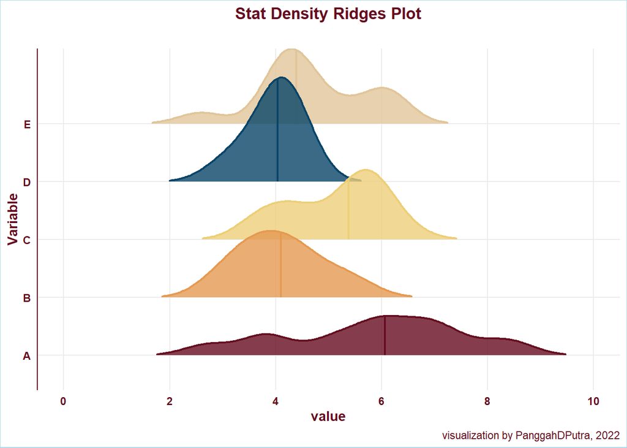

```r
stat_density_ridges_plot <- main_df %>%
  ggplot(aes(x = value,
             y = Variable,
             fill = Variable,
             color = Variable)) +
  ggridges::stat_density_ridges(quantile_lines = TRUE,
                                quantiles = 2,
                                alpha = .8,
                                size = .8,
                                rel_min_height = 0.01) +
  scale_color_manual(values = our_palette,
                     guide = 'none') +
  scale_fill_manual(values = our_palette,
                    guide = 'none') +
  scale_x_continuous(limits = c(0, 10),
                     breaks = seq(0, 10, by = 2)) +
  our_theme +
  theme(
    axis.line.x = element_blank()
  ) +
  labs(title = 'Stat Density Ridges Plot',
       subtitle = '',
       caption = 'visualization by PanggahDPutra, 2022')
```

## **Referensi**

- [Visual Vocabulary](https://github.com/Financial-Times/chart-doctor/tree/main/visual-vocabulary)
- [tidyverse](https://tidyverse.tidyverse.org/)
- scales
- [gapminder dataset](https://github.com/jennybc/gapminder)
- [iris dataset](https://stat.ethz.ch/R-manual/R-devel/library/datasets/html/iris.html)
- geomtextpath
- CGPfunctions
- ggbump
- ggalt
- [ggdist](https://github.com/mjskay/ggdist/)
- ggbeeswarm
- patchwork
- [ggridges](https://wilkelab.org/ggridges/)
- MetBrewer
- [flipbook_script.R](https://osf.io/vt2ny/)
- [Beyond Bar and Box Plots](https://z3tt.github.io/beyond-bar-and-box-plots)